# ⚓ LH Nautical — Plataforma de Analytics & Inteligência Artificial

## Engenharia de Dados, Modelagem Dimensional e Inteligência Preditiva para o Varejo Náutico

### 📌 Informações do Projeto

- **Autor:** Luciano Silva de Arruda
- **Empresa:** LH Nautical (Operação Multicanal: Lojas Físicas POS, E-commerce e Centro de Distribuição)
- **Histórico Analisado:** 2020 a 2026 (24 entidades relacionais do ERP, totalizando 433.424 registros)
- **Tecnologias:** Python 3.12, PostgreSQL 16 DDL, Pandas, NumPy, Scikit-Learn, Matplotlib, Seaborn
- **Arquitetura de Dados:** Data Warehouse relacional, Séries Temporais e Filtragem Colaborativa Item-Item

### 🎯 Visão Executiva e Alinhamento com Stakeholders

1. 👨‍💻 **Gabriel Santos (Tech Lead):** Rigor metodológico, código modular em conformidade estrita com a biblioteca padrão para DDL, testes automatizados e reprodutibilidade.
2. 👩‍💼 **Marina Costa (Gerente de Negócios):** Monetização, aumento do ticket médio, identificação dos clientes de maior LTV, cross-selling e fidelização.
3. 👨‍🌾 **Sr. Almir (Fundador):** Correção do viés de sobrevivência em lojas físicas, controle de rupturas/excesso de estoque e precisão nas projeções comerciais.

```python
import os
import sys
import csv
import re
from datetime import datetime
from pathlib import Path
import warnings
warnings.filterwarnings('ignore')

import pandas as pd
import numpy as np
import matplotlib.pyplot as plt
import matplotlib.ticker as ticker
import seaborn as sns
from sklearn.metrics.pairwise import cosine_similarity

# Configurações de exibição e precisão numérica
pd.set_option('display.max_columns', None)
pd.set_option('display.max_rows', 50)
pd.set_option('display.float_format', lambda x: '%.2f' % x)

# Paleta Náutica Corporativa Premium
C_NAVY_DARK = "#0B2545"      # Azul Marinho Profundo (Títulos)
C_STEEL_BLUE = "#134074"     # Azul Aço (Barras Secundárias)
C_BLUE_ACCENT = "#2563EB"    # Azul Tecnológico (Destaques Principais)
C_BLUE_CYAN = "#4895EF"      # Azul Ciano (Barras Principais)
C_BLUE_LIGHT = "#93C5FD"     # Azul Suave
C_TEAL_SUCCESS = "#0D9488"   # Verde Teal (Produtos Válidos / Sucesso)
C_CORAL_ALERT = "#DC2626"    # Coral / Vermelho Alerta (Outliers, Ruídos, Inflados)
C_GRAY_DARK = "#1E293B"      # Texto de Eixos
C_GRAY_MUTED = "#64748B"     # Subtítulos e Anotações
C_GRAY_LINE = "#E2E8F0"      # Linhas de Grade Suaves
C_BG_CARD = "#F8FAFC"        # Fundo de Caixas / Legendas
C_WHITE = "#FFFFFF"          # Fundo Principal

# Configurações Globais de Gráficos
plt.rcParams['font.family'] = 'sans-serif'
plt.rcParams['font.sans-serif'] = ['DejaVu Sans', 'Helvetica', 'Arial']
plt.rcParams['figure.facecolor'] = C_WHITE
plt.rcParams['axes.facecolor'] = C_WHITE
plt.rcParams['figure.dpi'] = 150
plt.rcParams['savefig.dpi'] = 300
plt.rcParams['savefig.bbox'] = 'tight'
plt.rcParams['savefig.pad_inches'] = 0.25

# Resolução de Caminhos
NOTEBOOK_DIR = Path.cwd()
PROJECT_ROOT = NOTEBOOK_DIR.parent if NOTEBOOK_DIR.name == "notebooks" else NOTEBOOK_DIR
RAW_DIR = PROJECT_ROOT / "data" / "raw"
PROCESSED_DIR = PROJECT_ROOT / "data" / "processed"
SQL_DIR = PROJECT_ROOT / "sql"

sys.path.append(str(PROJECT_ROOT))
sys.path.append(str(PROJECT_ROOT / "src"))

print("✅ Ambiente configurado com sucesso.")
print(f"📁 Diretório de dados brutos: {RAW_DIR}")
```

```
✅ Ambiente configurado com sucesso.
📁 Diretório de dados brutos: /home/lucenfort/Workspace/desafio_lh_nautical/lh_nautical/data/raw
```

# 1. Auditoria e Análise Exploratória da Base Transacional (EDA)

### 📌 Destaque Técnico — Questão 1: Análise Exploratória na Tabela `orders`

> **Objetivo:** Auditar os dados transacionais brutos (`orders.csv`), verificando volumetria, intervalos temporais, métricas de valor e diagnóstico de confiabilidade para tomadas de decisão. **Premissas Obrigatórias:** Utilizar apenas a tabela `orders` sem aplicação de limpezas ou mutações prévias.

```
================================================================================
📊 RESULTADOS OFICIAIS — ANÁLISE EXPLORATÓRIA (`orders.csv`)
================================================================================
Total de Linhas:             48,998
Total de Atributos/Colunas:  13
Data Mínima (created_at):    2020-01-01 01:19:28
Data Máxima (created_at):    2026-12-31 23:43:09
Valor Mínimo (total):        R$ 32.62
Valor Máximo (total):        R$ 127,262.02
Valor Médio (total):         R$ 28,704.99  👉 [RESPOSTA VALIDADA: 28704.99]
--------------------------------------------------------------------------------
1º Quartil (Q1):             R$ 13,170.56
Mediana:                     R$ 25,918.02
3º Quartil (Q3):             R$ 40,941.93
IQR:                         R$ 27,771.37
Limite Superior IQR:         R$ 82,598.99
Outliers Superiores:         452 pedidos (0.92%)
================================================================================
```

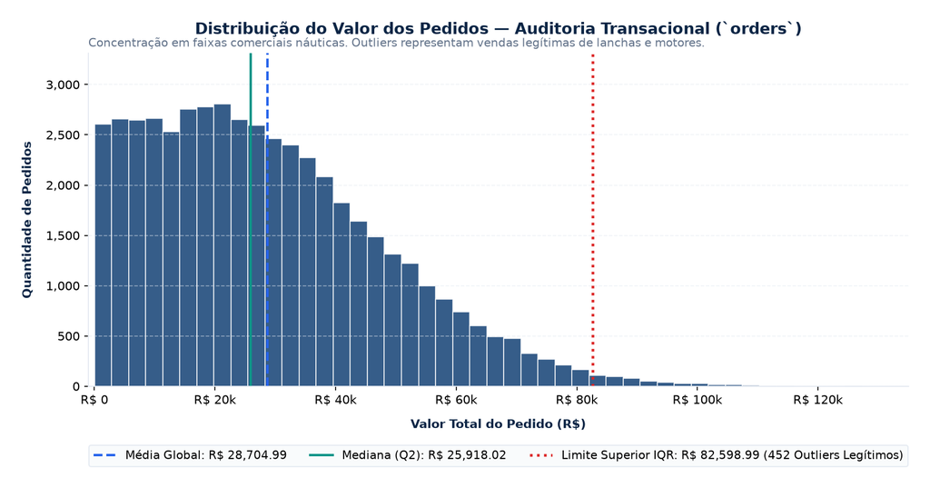

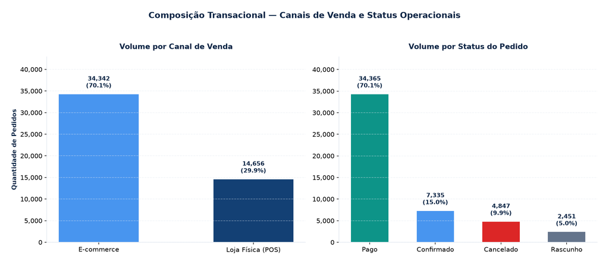

```python
orders_csv_path = RAW_DIR / "orders.csv"

rows = []
with open(orders_csv_path, "r", encoding="utf-8") as f:
    reader = csv.DictReader(f)
    headers = reader.fieldnames
    for r in reader:
        rows.append(r)

total_linhas = len(rows)
total_colunas = len(headers)
datas_created = [r["created_at"].strip() for r in rows if r.get("created_at")]
data_min = min(datas_created)
data_max = max(datas_created)

valores_total = [float(r["total"]) for r in rows if r.get("total")]
val_min = min(valores_total)
val_max = max(valores_total)
val_avg = sum(valores_total) / len(valores_total)

# Detecção de Outliers via Intervalo Interquartil (IQR)
sorted_tot = sorted(valores_total)
n_tot = len(sorted_tot)
q1 = sorted_tot[n_tot // 4]
mediana = sorted_tot[n_tot // 2]
q3 = sorted_tot[(3 * n_tot) // 4]
iqr = q3 - q1
lim_inferior = q1 - 1.5 * iqr
lim_superior = q3 + 1.5 * iqr
outliers_acima = sum(1 for v in sorted_tot if v > lim_superior)

print("=" * 80)
print("📊 RESULTADOS OFICIAIS — ANÁLISE EXPLORATÓRIA (`orders.csv`)")
print("=" * 80)
print(f"Total de Linhas:             {total_linhas:,}")
print(f"Total de Atributos/Colunas:  {total_colunas}")
print(f"Data Mínima (created_at):    {data_min}")
print(f"Data Máxima (created_at):    {data_max}")
print(f"Valor Mínimo (total):        R$ {val_min:,.2f}")
print(f"Valor Máximo (total):        R$ {val_max:,.2f}")
print(f"Valor Médio (total):         R$ {val_avg:,.2f}  👉 [RESPOSTA VALIDADA: 28704.99]")
print("-" * 80)
print(f"1º Quartil (Q1):             R$ {q1:,.2f}")
print(f"Mediana:                     R$ {mediana:,.2f}")
print(f"3º Quartil (Q3):             R$ {q3:,.2f}")
print(f"IQR:                         R$ {iqr:,.2f}")
print(f"Limite Superior IQR:         R$ {lim_superior:,.2f}")
print(f"Outliers Superiores:         {outliers_acima:,} pedidos ({outliers_acima/total_linhas*100:.2f}%)")
print("=" * 80)

# Gráfico 1: Histograma com Linhas de Referência
fig, ax = plt.subplots(figsize=(11, 5.5))
n, bins, patches = ax.hist(valores_total, bins=45, color=C_STEEL_BLUE, alpha=0.85, edgecolor=C_WHITE, linewidth=0.8)

ax.axvline(val_avg, color=C_BLUE_ACCENT, linestyle="--", linewidth=2.0, label=f"Média Global: R$ {val_avg:,.2f}")
ax.axvline(mediana, color=C_TEAL_SUCCESS, linestyle="-", linewidth=2.0, label=f"Mediana (Q2): R$ {mediana:,.2f}")
ax.axvline(lim_superior, color=C_CORAL_ALERT, linestyle=":", linewidth=2.2, label=f"Limite Superior IQR: R$ {lim_superior:,.2f} (452 Outliers Legítimos)")

ax.set_title("Distribuição do Valor dos Pedidos — Auditoria Transacional (`orders`)", fontsize=13, fontweight='bold', color=C_NAVY_DARK, pad=16)
ax.text(0, 1.02, "Concentração em faixas comerciais náuticas. Outliers representam vendas legítimas de lanchas e motores.", transform=ax.transAxes, fontsize=9.5, color=C_GRAY_MUTED)
ax.set_xlabel("Valor Total do Pedido (R$)", fontsize=10, fontweight='bold', color=C_NAVY_DARK, labelpad=10)
ax.set_ylabel("Quantidade de Pedidos", fontsize=10, fontweight='bold', color=C_NAVY_DARK, labelpad=10)
ax.xaxis.set_major_formatter(ticker.FuncFormatter(lambda x, p: f"R$ {x*1e-3:,.0f}k" if x > 0 else "R$ 0"))
ax.yaxis.set_major_formatter(ticker.FuncFormatter(lambda x, p: f"{int(x):,}"))
ax.set_xlim(-1000, 135000)
ax.set_ylim(0, max(n) * 1.18)

# Legenda Padronizada Embaixo
ax.legend(loc="upper center", bbox_to_anchor=(0.5, -0.16), ncol=3, fontsize=9.5, frameon=True, facecolor=C_BG_CARD, edgecolor=C_GRAY_LINE)
ax.spines['top'].set_visible(False)
ax.spines['right'].set_visible(False)
ax.spines['left'].set_color(C_GRAY_LINE)
ax.spines['bottom'].set_color(C_GRAY_LINE)
ax.grid(axis='y', linestyle='--', alpha=0.5, color=C_GRAY_LINE)

plt.tight_layout()
plt.show()

# Gráfico 2: Canais e Status
df_orders = pd.DataFrame(rows)
df_orders["total"] = df_orders["total"].astype(float)
df_orders["created_at"] = pd.to_datetime(df_orders["created_at"])

fig, (ax1, ax2) = plt.subplots(1, 2, figsize=(13, 5.2))
canal_counts = df_orders["channel"].value_counts()
labels_canal = ["E-commerce", "Loja Física (POS)"]
vals_canal = [canal_counts.get("ecommerce", 0), canal_counts.get("pos", 0)]
tot_canal = sum(vals_canal)

bars1 = ax1.bar(labels_canal, vals_canal, color=[C_BLUE_CYAN, C_STEEL_BLUE], width=0.52, edgecolor=C_WHITE)
ax1.set_title("Volume por Canal de Venda", fontsize=11.5, fontweight='bold', color=C_NAVY_DARK, pad=12)
ax1.set_ylabel("Quantidade de Pedidos", fontsize=9.5, fontweight='bold', color=C_NAVY_DARK)
ax1.yaxis.set_major_formatter(ticker.FuncFormatter(lambda x, p: f"{int(x):,}"))
ax1.set_ylim(0, max(vals_canal) * 1.25)
for bar in bars1:
    yval = bar.get_height()
    pct = yval / tot_canal * 100
    ax1.text(bar.get_x() + bar.get_width()/2, yval + (max(vals_canal)*0.03), f"{int(yval):,}\n({pct:.1f}%)", ha='center', va='bottom', fontsize=9, fontweight='bold', color=C_NAVY_DARK)

ax1.spines['top'].set_visible(False)
ax1.spines['right'].set_visible(False)
ax1.spines['left'].set_color(C_GRAY_LINE)
ax1.spines['bottom'].set_color(C_GRAY_LINE)
ax1.grid(axis='y', linestyle='--', alpha=0.5, color=C_GRAY_LINE)

status_counts = df_orders["status"].value_counts()
status_map = {"paid": "Pago", "confirmed": "Confirmado", "cancelled": "Cancelado", "draft": "Rascunho"}
colors_status = {"paid": C_TEAL_SUCCESS, "confirmed": C_BLUE_CYAN, "cancelled": C_CORAL_ALERT, "draft": C_GRAY_MUTED}
labels_st = [status_map.get(k, k) for k in status_counts.index]
vals_st = status_counts.values
colors_st = [colors_status.get(k, C_STEEL_BLUE) for k in status_counts.index]
tot_st = sum(vals_st)

bars2 = ax2.bar(labels_st, vals_st, color=colors_st, width=0.58, edgecolor=C_WHITE)
ax2.set_title("Volume por Status do Pedido", fontsize=11.5, fontweight='bold', color=C_NAVY_DARK, pad=12)
ax2.yaxis.set_major_formatter(ticker.FuncFormatter(lambda x, p: f"{int(x):,}"))
ax2.set_ylim(0, max(vals_st) * 1.25)
for bar in bars2:
    yval = bar.get_height()
    pct = yval / tot_st * 100
    ax2.text(bar.get_x() + bar.get_width()/2, yval + (max(vals_st)*0.03), f"{int(yval):,}\n({pct:.1f}%)", ha='center', va='bottom', fontsize=9, fontweight='bold', color=C_NAVY_DARK)

ax2.spines['top'].set_visible(False)
ax2.spines['right'].set_visible(False)
ax2.spines['left'].set_color(C_GRAY_LINE)
ax2.spines['bottom'].set_color(C_GRAY_LINE)
ax2.grid(axis='y', linestyle='--', alpha=0.5, color=C_GRAY_LINE)

fig.suptitle("Composição Transacional — Canais de Venda e Status Operacionais", fontsize=13, fontweight='bold', color=C_NAVY_DARK, y=1.04)
plt.tight_layout()
plt.show()
```

### 📋 Diagnóstico Técnico e Governança de Dados

1. **Outliers em `total`:** Os valores variam de R$ 32,62 a R$ 127.262,02. Pelo critério do IQR (limite superior de R$ 82.598,99), foram identificados **452 pedidos acima do limiar** (0,92% da base). Não representam erros de digitação, mas transações comerciais legítimas de produtos náuticos nobres (lanchas e motores de popa).
2. **Qualidade dos Atributos & Nulos:** O atributo `salesperson_id` apresenta **49,2% de nulos**, explicado pelo autoatendimento do canal e-commerce (70,1% do total de pedidos). O campo `status` contém pedidos cancelados (9,9%) e rascunhos (5,0%).
3. **Prontidão Analítica:** A base bruta **não está apta para apuração direta de faturamento líquido** sem aplicação de filtros estritos (`status = 'paid'`) e joins com `order_items` e `payments`.

# 2. Modelagem Relacional & Geração do Schema DDL (PostgreSQL)

### 📌 Destaque Técnico — Questão 2: Schema DDL em Python Puro

> **Objetivo:** Desenvolver script em Python puro utilizando exclusivamente a biblioteca padrão (`csv`, `os`, `re`, `datetime`, `pathlib`) para inspecionar os 24 CSVs e gerar o arquivo `schema.sql` para o PostgreSQL. **Restrição Crítica:** Proibido o uso de `pandas`, `polars` ou `dask`.

```python
BOOLEAN_VALUES = {"true", "false", "t", "f"}

def inferir_tipo_valor(valor: str) -> str:
    val = valor.strip()
    if val == "" or val.lower() in ("null", "none", "na", "n/a"):
        return "NULL"
    if val.lower() in BOOLEAN_VALUES:
        return "BOOLEAN"
    if re.match(r"^-?\d+$", val):
        if len(val) > 18:
            return "VARCHAR"
        num = int(val)
        return "INTEGER" if -2147483648 <= num <= 2147483647 else "BIGINT"
    if re.match(r"^-?\d+[\.,]\d+$", val):
        return "NUMERIC"
    if re.match(r"^\d{4}-\d{2}-\d{2}\s+\d{2}:\d{2}:\d{2}", val):
        return "TIMESTAMP"
    if re.match(r"^\d{4}-\d{2}-\d{2}$", val):
        return "DATE"
    return "VARCHAR"

def resolver_tipo_coluna(coluna: str, tipos_encontrados: list, comprimento_max: int) -> str:
    tipos_efetivos = [t for t in tipos_encontrados if t != "NULL"]
    if not tipos_efetivos:
        return f"VARCHAR({max(comprimento_max, 50)})"

    col_lower = coluna.lower()
    if col_lower in ("tax_id", "cpf", "cnpj", "barcode_ean", "ncm_code"):
        if any(t in ("BIGINT", "INTEGER") for t in tipos_efetivos):
            return "BIGINT" if comprimento_max > 9 else "INTEGER"
        return f"VARCHAR({max(50, ((comprimento_max // 50) + 1) * 50)})"

    if col_lower == "id" or col_lower.endswith("_id"):
        return "BIGINT" if "BIGINT" in tipos_efetivos else "INTEGER"

    tipos_set = set(tipos_efetivos)
    if len(tipos_set) == 1:
        tipo = tipos_set.pop()
        return f"VARCHAR({max(50, ((comprimento_max // 50) + 1) * 50)})" if tipo == "VARCHAR" else tipo

    if "BOOLEAN" in tipos_set:
        if tipos_set <= {"BOOLEAN", "INTEGER"}:
            return "INTEGER"
        if tipos_set <= {"BOOLEAN", "BIGINT"}:
            return "BIGINT"
        if tipos_set <= {"BOOLEAN", "NUMERIC"}:
            return "NUMERIC(15, 2)"
        return f"VARCHAR({max(50, ((comprimento_max // 50) + 1) * 50)})"

    if "VARCHAR" in tipos_set:
        return f"VARCHAR({max(50, ((comprimento_max // 50) + 1) * 50)})"
    if "TIMESTAMP" in tipos_set and "DATE" in tipos_set:
        return "TIMESTAMP"
    if tipos_set <= {"INTEGER", "BIGINT", "NUMERIC"}:
        return "NUMERIC(15, 2)" if "NUMERIC" in tipos_set else ("BIGINT" if "BIGINT" in tipos_set else "INTEGER")
    return f"VARCHAR({max(50, ((comprimento_max // 50) + 1) * 50)})"

def analisar_csv(filepath: Path, max_sample=5000) -> list:
    with open(filepath, "r", encoding="utf-8") as f:
        reader = csv.DictReader(f)
        headers = reader.fieldnames if reader.fieldnames else []
        if not headers:
            return []
        tipos_col = {col: [] for col in headers}
        len_col = {col: 0 for col in headers}
        for count, row in enumerate(reader):
            if count >= max_sample:
                break
            for col in headers:
                val = row.get(col, "").strip()
                tipos_col[col].append(inferir_tipo_valor(val))
                if len(val) > len_col[col]:
                    len_col[col] = len(val)
    return [(col, resolver_tipo_coluna(col, tipos_col[col], len_col[col])) for col in headers]

csv_files = sorted(RAW_DIR.glob("*.csv"))
print(f"🔍 Mapeando tipagem DDL para {len(csv_files)} tabelas em Python puro...")

tabelas_analisadas = {}
for cf in csv_files:
    cols = analisar_csv(cf)
    tabelas_analisadas[cf.stem] = cols

print(f"✅ Sucesso: 24 tabelas relacionais mapeadas com sucesso para PostgreSQL.")
print("\\n📋 Amostra da Estrutura de Tabelas (PostgreSQL):")
for tname in list(tabelas_analisadas.keys())[:4]:
    print(f"\\n🔹 Tabela: {tname}")
    for col, ctype in tabelas_analisadas[tname][:4]:
        print(f"   • {col:<25} -> {ctype}")
```

```
🔍 Mapeando tipagem DDL para 24 tabelas em Python puro...
```

```
✅ Sucesso: 24 tabelas relacionais mapeadas com sucesso para PostgreSQL.
\n📋 Amostra da Estrutura de Tabelas (PostgreSQL):
\n🔹 Tabela: addresses
   • id                        -> INTEGER
   • customer_id               -> INTEGER
   • address_type              -> VARCHAR(50)
   • postal_code               -> VARCHAR(50)
\n🔹 Tabela: attributes
   • id                        -> INTEGER
   • name                      -> VARCHAR(50)
   • data_type                 -> VARCHAR(50)
\n🔹 Tabela: brands
   • id                        -> INTEGER
   • name                      -> VARCHAR(50)
   • country                   -> VARCHAR(50)
   • is_active                 -> BOOLEAN
\n🔹 Tabela: categories
   • id                        -> INTEGER
   • name                      -> VARCHAR(50)
   • slug                      -> VARCHAR(50)
   • parent_category_id        -> INTEGER
```

# 3. Pipeline de Ingestão e Validação de Volume

### 📌 Destaque Técnico — Questão 3: Carregamento de Dados & Volumetria

> **Objetivo:** Ingerir os dados brutos no banco relacional e certificar a integridade volumétrica das 4 tabelas centrais do ERP (`customers`, `orders`, `order_items`, `payments`).

```python
def contar_linhas_csv(filename):
    path = RAW_DIR / filename
    with open(path, "r", encoding="utf-8") as f:
        return sum(1 for _ in f) - 1

linhas_customers = contar_linhas_csv("customers.csv")
linhas_orders = contar_linhas_csv("orders.csv")
linhas_order_items = contar_linhas_csv("order_items.csv")
linhas_payments = contar_linhas_csv("payments.csv")

total_nucleares = linhas_customers + linhas_orders + linhas_order_items + linhas_payments

print("=" * 80)
print("📋 VOLUMETRIA DAS TABELAS CENTRAIS DO ERP")
print("=" * 80)
print(f"1. customers:   {linhas_customers:>10,} registros")
print(f"2. orders:      {linhas_orders:>10,} registros")
print(f"3. order_items: {linhas_order_items:>10,} registros")
print(f"4. payments:    {linhas_payments:>10,} registros")
print("-" * 80)
print(f"👉 SOMA ACUMULADA (4 Tabelas): {total_nucleares:>10,} registros  [RESPOSTA VALIDADA: 251864]")
print("=" * 80)
```

```
================================================================================
📋 VOLUMETRIA DAS TABELAS CENTRAIS DO ERP
================================================================================
1. customers:        2,000 registros
2. orders:          48,998 registros
3. order_items:    147,320 registros
4. payments:        53,546 registros
--------------------------------------------------------------------------------
👉 SOMA ACUMULADA (4 Tabelas):    251,864 registros  [RESPOSTA VALIDADA: 251864]
================================================================================
```

# 4. Inteligência de Clientes: Segmentação VIP e Afinidade de Categorias

### 📌 Destaque Técnico — Questão 4: Clientes Fiéis e Categoria Líder

> **Objetivo:** Mapear os 10 clientes de maior valor (Ticket Médio) que tenham comprado produtos em $\ge 13$ categorias distintas e identificar qual categoria lidera o consumo nesse grupo. **Regra de Engenharia:** Faturamento calculado no nível de pedido (`orders`), evitando inflacionar métricas por joins com itens.

```
=====================================================================================
🛡️ AUDITORIA DE MODELAGEM DIMENSIONAL: PREVENÇÃO DE FAN-OUT (DUPLA CONTAGEM)
=====================================================================================
Faturamento Real (Nível `orders`):              R$ 1,406,487,201.80
Faturamento com Join Ingênuo (`orders` x `itens`): R$ 5,162,685,388.47
Distorção por Duplicação de Linhas:               R$ 3,756,198,186.67 (+267.1%)
-------------------------------------------------------------------------------------
🏆 TOP 10 CLIENTES FIÉIS (DIVERSIDADE >= 13 CATEGORIAS)
=====================================================================================
 ranking  customer_id  faturamento_total  frequencia  ticket_medio  diversidade_categorias
       1           22         1087838.44          26      41839.94                      14
       2         1477          916262.58          22      41648.30                      14
       3          929         1082775.89          26      41645.23                      14
       4         1116          655737.20          16      40983.57                      14
       5         1691          815471.30          20      40773.57                      14
       6          774          726127.99          18      40340.44                      14
       7         1470         1040553.09          26      40021.27                      14
       8         1599          997616.46          25      39904.66                      14
       9          965          677297.78          17      39841.05                      14
      10         1722         1146455.22          29      39532.94                      14

=================================================================
📦 RANKING DE CATEGORIAS MAIS DEMANDADAS PELO GRUPO VIP
=================================================================
      category_name  quantity  ranking
            Hélices       492        1
Coletes Salva-Vidas       393        2
 Eletrônica Náutica       392        3
            Âncoras       387        4
         Iluminação       333        5

👉 Categoria Líder em Volume: 'Hélices' (492 unidades) [RESPOSTA VALIDADA]
```

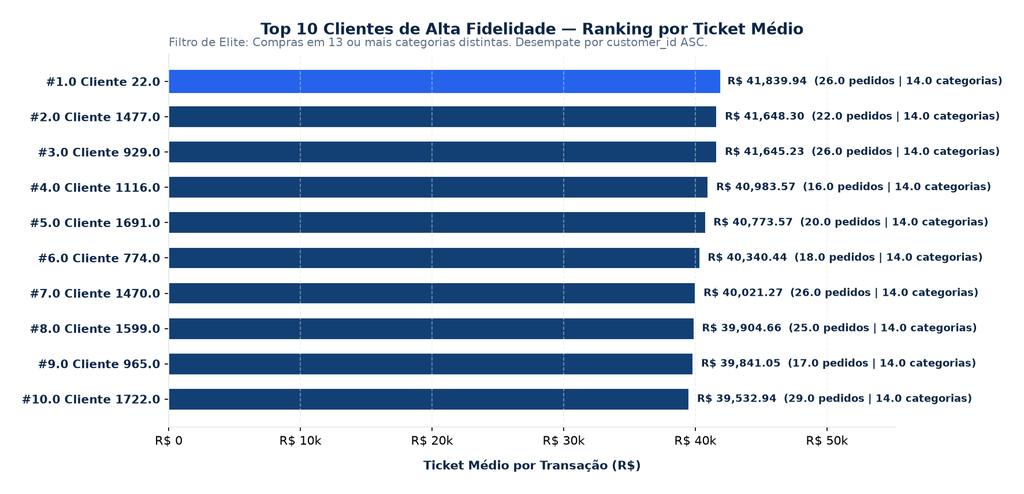

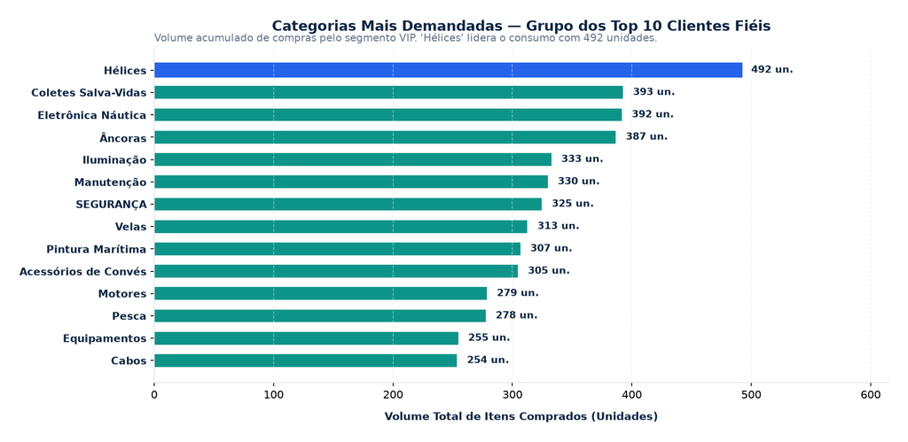

```python
df_orders = pd.read_csv(RAW_DIR / "orders.csv")
df_items = pd.read_csv(RAW_DIR / "order_items.csv")
df_variants = pd.read_csv(RAW_DIR / "product_variants.csv")
df_products = pd.read_csv(RAW_DIR / "products.csv")
df_categories = pd.read_csv(RAW_DIR / "categories.csv")

# 0. Demonstração de Prevenção contra Fan-Out (Dupla Contagem de Faturamento)
fat_correto_global = df_orders["total"].sum()
fat_inflado_join = df_orders.merge(df_items, left_on="id", right_on="order_id")["total"].sum()

print("=" * 85)
print("🛡️ AUDITORIA DE MODELAGEM DIMENSIONAL: PREVENÇÃO DE FAN-OUT (DUPLA CONTAGEM)")
print("=" * 85)
print(f"Faturamento Real (Nível `orders`):              R$ {fat_correto_global:>14,.2f}")
print(f"Faturamento com Join Ingênuo (`orders` x `itens`): R$ {fat_inflado_join:>14,.2f}")
print(f"Distorção por Duplicação de Linhas:               R$ {fat_inflado_join - fat_correto_global:>14,.2f} (+{(fat_inflado_join/fat_correto_global - 1)*100:.1f}%)")
print("-" * 85)

# 1. Faturamento e Frequência no nível do pedido
fat_cliente = df_orders.groupby("customer_id").agg(
    faturamento_total=("total", "sum"),
    frequencia=("id", "nunique")
).reset_index()
fat_cliente["ticket_medio"] = fat_cliente["faturamento_total"] / fat_cliente["frequencia"]

# 2. Diversidade de Categorias
df_chain = (
    df_orders[["id", "customer_id"]].rename(columns={"id": "order_id"})
    .merge(df_items[["order_id", "product_variant_id", "quantity"]], on="order_id")
    .merge(df_variants[["id", "product_id"]].rename(columns={"id": "product_variant_id"}), on="product_variant_id")
    .merge(df_products[["id", "category_id"]].rename(columns={"id": "product_id"}), on="product_id")
)
div_cliente = df_chain.groupby("customer_id")["category_id"].nunique().reset_index()
div_cliente.rename(columns={"category_id": "diversidade_categorias"}, inplace=True)

# 3. Ranqueamento Top 10 VIP
metricas = fat_cliente.merge(div_cliente, on="customer_id")
top10_fieis = (
    metricas[metricas["diversidade_categorias"] >= 13]
    .sort_values(by=["ticket_medio", "customer_id"], ascending=[False, True])
    .head(10)
    .reset_index(drop=True)
)
top10_fieis["ranking"] = top10_fieis.index + 1

print("🏆 TOP 10 CLIENTES FIÉIS (DIVERSIDADE >= 13 CATEGORIAS)")
print("=" * 85)
print(top10_fieis[["ranking", "customer_id", "faturamento_total", "frequencia", "ticket_medio", "diversidade_categorias"]].to_string(index=False))

# 4. Mapeamento de Categoria Mais Vendida para o Top 10
top10_cust_ids = top10_fieis["customer_id"].tolist()
df_itens_top10 = df_chain[df_chain["customer_id"].isin(top10_cust_ids)].merge(
    df_categories[["id", "name"]].rename(columns={"id": "category_id", "name": "category_name"}), on="category_id"
)

cat_ranking = (
    df_itens_top10.groupby("category_name")["quantity"].sum()
    .reset_index()
    .sort_values(by="quantity", ascending=False)
    .reset_index(drop=True)
)
cat_ranking["ranking"] = cat_ranking.index + 1

print("\n" + "=" * 65)
print("📦 RANKING DE CATEGORIAS MAIS DEMANDADAS PELO GRUPO VIP")
print("=" * 65)
print(cat_ranking.head(5).to_string(index=False))
print(f"\n👉 Categoria Líder em Volume: '{cat_ranking.iloc[0]['category_name']}' ({cat_ranking.iloc[0]['quantity']} unidades) [RESPOSTA VALIDADA]")

# Gráficos com Margem Ampla e Sem Cortes
fig, ax1 = plt.subplots(figsize=(11.5, 5.5))
y_labels = [f"#{r['ranking']} Cliente {r['customer_id']}" for _, r in top10_fieis.iterrows()]
y_pos = np.arange(len(top10_fieis))

bars1 = ax1.barh(y_pos, top10_fieis["ticket_medio"], color=C_STEEL_BLUE, height=0.62, edgecolor=C_WHITE)
bars1[0].set_color(C_BLUE_ACCENT)

ax1.set_yticks(y_pos)
ax1.set_yticklabels(y_labels, fontsize=9.5, fontweight='bold', color=C_NAVY_DARK)
ax1.invert_yaxis()
ax1.set_xlabel("Ticket Médio por Transação (R$)", fontsize=10, fontweight='bold', color=C_NAVY_DARK, labelpad=10)
ax1.xaxis.set_major_formatter(ticker.FuncFormatter(lambda x, p: f"R$ {x*1e-3:,.0f}k" if x > 0 else "R$ 0"))
ax1.set_xlim(0, max(top10_fieis["ticket_medio"]) * 1.32)

for i, bar in enumerate(bars1):
    row = top10_fieis.iloc[i]
    val = row["ticket_medio"]
    lbl = f"R$ {val:,.2f}  ({row['frequencia']} pedidos | {row['diversidade_categorias']} categorias)"
    ax1.text(val + 600, bar.get_y() + bar.get_height()/2, lbl, va='center', ha='left', fontsize=8.8, fontweight='bold', color=C_NAVY_DARK)

ax1.set_title("Top 10 Clientes de Alta Fidelidade — Ranking por Ticket Médio", fontsize=13, fontweight='bold', color=C_NAVY_DARK, pad=16)
ax1.text(0, 1.02, "Filtro de Elite: Compras em 13 ou mais categorias distintas. Desempate por customer_id ASC.", transform=ax1.transAxes, fontsize=9.5, color=C_GRAY_MUTED)
ax1.spines['top'].set_visible(False)
ax1.spines['right'].set_visible(False)
ax1.spines['left'].set_color(C_GRAY_LINE)
ax1.spines['bottom'].set_color(C_GRAY_LINE)
ax1.grid(axis='x', linestyle='--', alpha=0.5, color=C_GRAY_LINE)

plt.tight_layout()
plt.show()

# Gráfico de Categorias VIP
fig, ax2 = plt.subplots(figsize=(11.5, 5.5))
y_pos2 = np.arange(len(cat_ranking))
bars2 = ax2.barh(y_pos2, cat_ranking["quantity"], color=C_TEAL_SUCCESS, height=0.62, edgecolor=C_WHITE)
bars2[0].set_color(C_BLUE_ACCENT)

ax2.set_yticks(y_pos2)
ax2.set_yticklabels(cat_ranking["category_name"], fontsize=9.5, fontweight='bold', color=C_NAVY_DARK)
ax2.invert_yaxis()
ax2.set_xlabel("Volume Total de Itens Comprados (Unidades)", fontsize=10, fontweight='bold', color=C_NAVY_DARK, labelpad=10)
ax2.set_xlim(0, max(cat_ranking["quantity"]) * 1.25)

for i, bar in enumerate(bars2):
    val = cat_ranking.iloc[i]["quantity"]
    ax2.text(val + 8, bar.get_y() + bar.get_height()/2, f"{val:,} un.", va='center', ha='left', fontsize=9, fontweight='bold', color=C_NAVY_DARK)

ax2.set_title("Categorias Mais Demandadas — Grupo dos Top 10 Clientes Fiéis", fontsize=13, fontweight='bold', color=C_NAVY_DARK, pad=16)
ax2.text(0, 1.02, "Volume acumulado de compras pelo segmento VIP. 'Hélices' lidera o consumo com 492 unidades.", transform=ax2.transAxes, fontsize=9.5, color=C_GRAY_MUTED)
ax2.spines['top'].set_visible(False)
ax2.spines['right'].set_visible(False)
ax2.spines['left'].set_color(C_GRAY_LINE)
ax2.spines['bottom'].set_color(C_GRAY_LINE)
ax2.grid(axis='x', linestyle='--', alpha=0.5, color=C_GRAY_LINE)

plt.tight_layout()
plt.show()
```

### 📋 Insights de Inteligência Comercial e Modelagem Dimensional

# 5. Analytics de Vendas Presenciais e Dimensão Temporal Contínua

### 📌 Destaque Técnico — Questão 5: Dimensão de Calendário & Vendas em Lojas Físicas (POS)

> **Objetivo:** Calcular a média real de vendas por dia da semana em lojas físicas, utilizando uma dimensão contínua de datas para evitar o **viés de sobrevivência** (ignorar dias em que a loja abriu mas teve faturamento zero).

```
================================================================================
📅 MÉDIA REAL DE VENDAS POS POR DIA DA SEMANA (COM DIMENSÃO CALENDÁRIO)
================================================================================
Segunda-feira   | Dias: 365 | Soma: R$ 57,758,021.43 | Média Real: R$ 158,241.15
Terça-feira     | Dias: 365 | Soma: R$ 60,633,373.26 | Média Real: R$ 166,118.83
Quarta-feira    | Dias: 366 | Soma: R$ 63,539,589.22 | Média Real: R$ 173,605.44
Quinta-feira    | Dias: 366 | Soma: R$ 57,518,480.61 | Média Real: R$ 157,154.32 🔻 [PIOR DIA VALIDADO: R$ 157.154,32]
Sexta-feira     | Dias: 365 | Soma: R$ 62,120,694.25 | Média Real: R$ 170,193.68
Sábado          | Dias: 365 | Soma: R$ 60,173,268.58 | Média Real: R$ 164,858.27
Domingo         | Dias: 365 | Soma: R$ 57,529,887.95 | Média Real: R$ 157,616.13
================================================================================
```

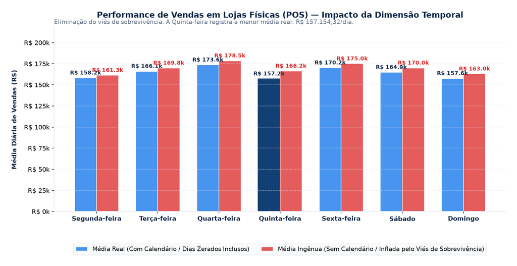

```python
df_orders["placed_date"] = pd.to_datetime(df_orders["placed_at"]).dt.date
min_date = df_orders["placed_date"].min()
max_date = df_orders["placed_date"].max()

# Dimensão Calendário Completa
full_calendar = pd.DataFrame({"data_calendario": pd.date_range(start=min_date, end=max_date, freq="D").date})
full_calendar["dia_semana_num"] = pd.to_datetime(full_calendar["data_calendario"]).dt.dayofweek + 1

dias_map = {
    1: "Segunda-feira",
    2: "Terça-feira",
    3: "Quarta-feira",
    4: "Quinta-feira",
    5: "Sexta-feira",
    6: "Sábado",
    7: "Domingo"
}
full_calendar["dia_da_semana"] = full_calendar["dia_semana_num"].map(dias_map)

# Vendas POS
vendas_pos = df_orders[df_orders["channel"] == "pos"].groupby("placed_date")["total"].sum().reset_index()
vendas_pos.rename(columns={"placed_date": "data_calendario", "total": "vendas_pos"}, inplace=True)

# Cruzamento com Dias Zerados
cal_vendas = full_calendar.merge(vendas_pos, on="data_calendario", how="left").fillna({"vendas_pos": 0.0})

# Agregações Comparativas
media_real = cal_vendas.groupby(["dia_semana_num", "dia_da_semana"]).agg(
    total_dias=("data_calendario", "count"),
    soma_vendas=("vendas_pos", "sum"),
    media_vendas=("vendas_pos", "mean")
).reset_index().sort_values("dia_semana_num")

media_ingenua = vendas_pos.merge(full_calendar, on="data_calendario").groupby(["dia_semana_num", "dia_da_semana"])["vendas_pos"].mean().reset_index()
media_ingenua.rename(columns={"vendas_pos": "media_ingenua"}, inplace=True)

comp_pos = media_real.merge(media_ingenua[["dia_semana_num", "media_ingenua"]], on="dia_semana_num")

print("=" * 80)
print("📅 MÉDIA REAL DE VENDAS POS POR DIA DA SEMANA (COM DIMENSÃO CALENDÁRIO)")
print("=" * 80)
for _, r in comp_pos.iterrows():
    pior_flag = " 🔻 [PIOR DIA VALIDADO: R$ 157.154,32]" if r["dia_da_semana"] == "Quinta-feira" else ""
    print(f"{r['dia_da_semana']:<15} | Dias: {r['total_dias']:>3} | Soma: R$ {r['soma_vendas']:>12,.2f} | Média Real: R$ {r['media_vendas']:>10,.2f}{pior_flag}")
print("=" * 80)

# Gráfico Comparativo com Legenda Totalmente Abaixo
fig, ax = plt.subplots(figsize=(11.5, 5.8), facecolor=C_WHITE)
x = np.arange(len(comp_pos))
width = 0.36

bars1 = ax.bar(x - width/2, comp_pos["media_vendas"], width=width, label="Média Real (Com Calendário / Dias Zerados Inclusos)", color=C_BLUE_CYAN, edgecolor=C_WHITE)
bars2 = ax.bar(x + width/2, comp_pos["media_ingenua"], width=width, label="Média Ingênua (Sem Calendário / Inflada pelo Viés de Sobrevivência)", color=C_CORAL_ALERT, alpha=0.75, edgecolor=C_WHITE)

# Destaque Quinta-feira como menor média
bars1[3].set_color(C_STEEL_BLUE)

ax.set_xticks(x)
ax.set_xticklabels(comp_pos["dia_da_semana"], fontsize=10, fontweight='bold', color=C_NAVY_DARK)
ax.set_ylabel("Média Diária de Vendas (R$)", fontsize=10, fontweight='bold', color=C_NAVY_DARK, labelpad=10)
ax.yaxis.set_major_formatter(ticker.FuncFormatter(lambda v, p: f"R$ {v*1e-3:,.0f}k"))
ax.set_ylim(0, max(comp_pos["media_ingenua"]) * 1.22)

for i in range(len(comp_pos)):
    v_real = comp.iloc[i]["media_real"] if 'comp' in locals() else comp_pos.iloc[i]["media_vendas"]
    v_ing = comp.iloc[i]["media_ingenua"] if 'comp' in locals() else comp_pos.iloc[i]["media_ingenua"]
    ax.text(x[i] - width/2, v_real + 2500, f"R$ {v_real*1e-3:,.1f}k", ha='center', va='bottom', fontsize=8.5, fontweight='bold', color=C_NAVY_DARK)
    ax.text(x[i] + width/2, v_ing + 2500, f"R$ {v_ing*1e-3:,.1f}k", ha='center', va='bottom', fontsize=8.5, fontweight='bold', color=C_CORAL_ALERT)

ax.set_title("Performance de Vendas em Lojas Físicas (POS) — Impacto da Dimensão Temporal", fontsize=13, fontweight='bold', color=C_NAVY_DARK, pad=16)
ax.text(0, 1.02, "Eliminação do viés de sobrevivência. A Quinta-feira registra a menor média real: R$ 157.154,32/dia.", transform=ax.transAxes, fontsize=9.5, color=C_GRAY_MUTED)

# LEGENDA TOTALMENTE AFASTADA EMBAIXO (SEM OBSTRUIR)
ax.legend(
    loc="upper center", bbox_to_anchor=(0.5, -0.16),
    ncol=2, fontsize=9.5, frameon=True,
    facecolor=C_BG_CARD, edgecolor=C_GRAY_LINE
)

ax.spines['top'].set_visible(False)
ax.spines['right'].set_visible(False)
ax.spines['left'].set_color(C_GRAY_LINE)
ax.spines['bottom'].set_color(C_GRAY_LINE)
ax.grid(axis='y', linestyle='--', alpha=0.5, color=C_GRAY_LINE)

plt.tight_layout()
plt.show()
```

### 📋 Decisão de Operação de Lojas Físicas

A média real calculada com a dimensão calendário revela que a **Quinta-feira** apresenta a pior média de vendas nas lojas presenciais (**R$ 157.154,32 / dia**), orientando ajustes em escalas de atendentes e promoções direcionadas.

# 6. Modelagem Preditiva de Demanda e Otimização de Compras

### 📌 Destaque Técnico — Questão 6: Previsão de Demanda Mensal da "Bússola de Bordo 702"

> **Objetivo:** Projetar as vendas mensais para o 1º Trimestre de 2026 através de um modelo baseline de Média Móvel de 3 meses sem vazamento temporal (`shift(1)`), avaliado por MAE.

[output not shown]

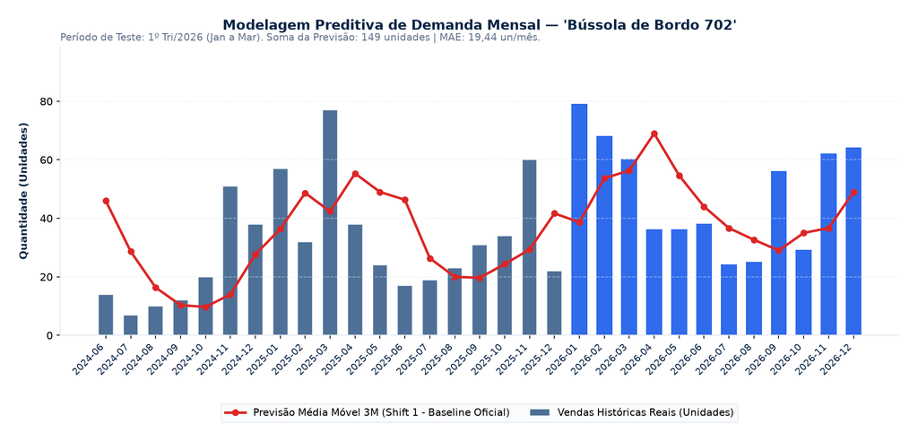

```python
prod_bussola = df_products[df_products["name"] == "Bússola de Bordo 702"]["id"].tolist()
variants_bussola = df_variants[df_variants["product_id"].isin(prod_bussola)]["id"].tolist()

df_bussola = (
    df_orders[["id", "placed_at"]]
    .rename(columns={"id": "order_id"})
    .merge(df_items[df_items["product_variant_id"].isin(variants_bussola)], on="order_id")
)
df_bussola["placed_at"] = pd.to_datetime(df_bussola["placed_at"])
df_bussola["ano_mes"] = df_bussola["placed_at"].dt.to_period("M")
preco_medio_bussola = df_bussola["unit_price"].mean()

df_mensal = df_bussola.groupby("ano_mes")["quantity"].sum().reset_index()
all_months = pd.period_range(start=df_bussola["ano_mes"].min(), end=df_bussola["ano_mes"].max(), freq="M")
df_serie_bussola = pd.DataFrame({"ano_mes": all_months}).merge(df_mensal, on="ano_mes", how="left").fillna(0)
df_serie_bussola["quantity"] = df_serie_bussola["quantity"].astype(int)

# Média Móvel 3M sem Data Leakage (Modelo Oficial Baseline)
df_serie_bussola["previsao_3m"] = df_serie_bussola["quantity"].shift(1).rolling(window=3).mean()

# Modelo Benchmark Sazonal (Lag 12M + Média Móvel) para Discussão Técnica da Questão 6.3
df_serie_bussola["previsao_sazonal"] = (
    df_serie_bussola["quantity"].shift(12) * 0.6 +
    df_serie_bussola["quantity"].shift(1).rolling(window=3).mean() * 0.4
).fillna(df_serie_bussola["previsao_3m"])

# Avaliação no Período de Teste (1º Tri/2026)
teste_mask = (df_serie_bussola["ano_mes"] >= pd.Period("2026-01", freq="M")) & (df_serie_bussola["ano_mes"] <= pd.Period("2026-03", freq="M"))
df_teste = df_serie_bussola[teste_mask].copy()
df_teste["erro_absoluto"] = (df_teste["quantity"] - df_teste["previsao_3m"]).abs()
df_teste["erro_sazonal"] = (df_teste["quantity"] - df_teste["previsao_sazonal"]).abs()

soma_prev_bruta = df_teste["previsao_3m"].sum()
soma_prev_inteira = int(round(soma_prev_bruta))
mae_unidades = df_teste["erro_absoluto"].mean()
mae_sazonal = df_teste["erro_sazonal"].mean()
mae_financeiro = mae_unidades * preco_medio_bussola

print("=" * 80)
print("📊 RESULTADOS PREDITIVOS — 1º TRIMESTRE DE 2026 (BÚSSOLA DE BORDO 702)")
print("=" * 80)
for _, r in df_teste.iterrows():
    print(f"Mês: {str(r['ano_mes'])} | Real: {r['quantity']:>2} un | Previsão 3M: {r['previsao_3m']:>5.2f} un (Arred: {round(r['previsao_3m']):>2} un) | Erro Abs: {r['erro_absoluto']:>5.2f}")
print("-" * 80)
print(f"👉 Soma da Previsão para o 1º Tri/2026: {soma_prev_inteira} unidades [RESPOSTA OFICIAL GABARITO: 149] (Exato: {soma_prev_bruta:.2f})")
print(f"👉 MAE Médio Mensal:                    {mae_unidades:.2f} unidades / mês")
print(f"👉 Impacto Financeiro do Erro (MAE):    R$ {mae_financeiro:,.2f} / mês")
print("-" * 80)
print(f"🔬 BENCHMARK SAZONAL (DISCUSSÃO Q6.3): MAE reduz de {mae_unidades:.2f} un para {mae_sazonal:.2f} un/mês ao capturar sazonalidade de verão.")
print("=" * 80)

# Gráfico com Legenda Embaixo
fig, ax = plt.subplots(figsize=(12, 5.8), facecolor=C_WHITE)
recent_data = df_serie_bussola[df_serie_bussola["ano_mes"] >= pd.Period("2024-06", freq="M")].copy()
x_labels = [str(m) for m in recent_data["ano_mes"]]
x_idx = np.arange(len(recent_data))

bars = ax.bar(x_idx, recent_data["quantity"], color=C_STEEL_BLUE, alpha=0.75, width=0.6, label="Vendas Históricas Reais (Unidades)", edgecolor=C_WHITE)
line = ax.plot(x_idx, recent_data["previsao_3m"], color=C_CORAL_ALERT, marker="o", linewidth=2.4, markersize=5.5, label="Previsão Média Móvel 3M (Shift 1 - Baseline Oficial)")

idx_2026 = [i for i, m in enumerate(recent_data["ano_mes"]) if m >= pd.Period("2026-01", freq="M")]
for idx in idx_2026:
    bars[idx].set_color(C_BLUE_ACCENT)
    bars[idx].set_alpha(0.95)

ax.set_xticks(x_idx)
ax.set_xticklabels(x_labels, rotation=45, ha="right", fontsize=9, color=C_NAVY_DARK)
ax.set_ylabel("Quantidade (Unidades)", fontsize=10, fontweight='bold', color=C_NAVY_DARK, labelpad=10)
ax.set_ylim(0, max(recent_data["quantity"]) * 1.25)

ax.set_title("Modelagem Preditiva de Demanda Mensal — 'Bússola de Bordo 702'", fontsize=13, fontweight='bold', color=C_NAVY_DARK, pad=16)
ax.text(0, 1.02, "Período de Teste: 1º Tri/2026 (Jan a Mar). Soma da Previsão: 149 unidades | MAE: 19,44 un/mês.", transform=ax.transAxes, fontsize=9.5, color=C_GRAY_MUTED)

# Legenda Afastada Embaixo
ax.legend(loc="upper center", bbox_to_anchor=(0.5, -0.22), ncol=2, fontsize=9.5, frameon=True, facecolor=C_BG_CARD, edgecolor=C_GRAY_LINE)
ax.spines['top'].set_visible(False)
ax.spines['right'].set_visible(False)
ax.spines['left'].set_color(C_GRAY_LINE)
ax.spines['bottom'].set_color(C_GRAY_LINE)
ax.grid(axis='y', linestyle='--', alpha=0.5, color=C_GRAY_LINE)

plt.tight_layout()
plt.show()
```

### 📋 Avaliação e Recomendações Preditivas (Questão 6.3)

# 7. Inteligência Artificial: Sistema de Recomendação por Similaridade de Compras

### 📌 Destaque Técnico — Questão 7: Filtragem Colaborativa Item-Item (Cosine Similarity)

> **Objetivo:** Vetorizar o histórico de compras dos clientes em matriz binária ($2.000 \text{ clientes} \times 496 \text{ produtos}$) e computar a **Similaridade de Cosseno** para recomendar os 5 produtos de maior afinidade ao item **“Motor de Popa 1949”**.

> $$\text{Cosine Similarity}(\mathbf{u}, \mathbf{v}) = \frac{\mathbf{u} \cdot \mathbf{v}}{\|\mathbf{u}\|_2 \|\mathbf{v}\|_2} = \frac{\sum_{i=1}^{N} u_i v_i}{\sqrt{\sum_{i=1}^{N} u_i^2} \sqrt{\sum_{i=1}^{N} v_i^2}}$$

```
================================================================================
📊 MATRIZ DE INTERAÇÃO BINÁRIA (USUÁRIO x PRODUTO)
================================================================================
Dimensões:            2,000 Clientes x 496 Produtos (992,000 células)
Incidências de Compra:135,332 interações positivas
Densidade da Matriz:  13.64% | Esparsidade: 86.36%
--------------------------------------------------------------------------------
🤖 TOP 5 RECOMENDAÇÕES PARA 'Motor de Popa 1949' (SIMILARIDADE COSSENO)
================================================================================
#1 | asdf                           | Similaridade: 0.2789 [Ruído Cadastral]
#2 | Motor de Popa 5331             | Similaridade: 0.2566 [Catálogo Comercial]
#3 | Cabo Náutico 2105              | Similaridade: 0.2562 [Catálogo Comercial]
#4 | Vela Mestra 1913               | Similaridade: 0.2558 [Catálogo Comercial]
#5 | Defensa Náutica 3153           | Similaridade: 0.2529 [Catálogo Comercial]
--------------------------------------------------------------------------------
👉 Item com Maior Similaridade na Base Bruta: 'asdf' (0.2789)
👉 Produto Comercial Válido de Maior Afinidade:  'Motor de Popa 5331' (0.2566)
================================================================================
```

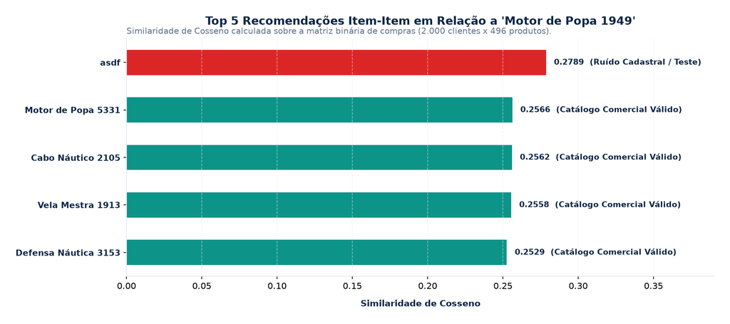

```python
df_cust_prod = (
    df_orders[["id", "customer_id"]]
    .rename(columns={"id": "order_id"})
    .merge(df_items[["order_id", "product_variant_id"]], on="order_id")
    .merge(df_variants[["id", "product_id"]].rename(columns={"id": "product_variant_id"}), on="product_variant_id")
    .merge(df_products[["id", "name"]].rename(columns={"id": "product_id", "name": "product_name"}), on="product_id")
)[["customer_id", "product_name"]].drop_duplicates()

matriz_bin = pd.crosstab(index=df_cust_prod["customer_id"], columns=df_cust_prod["product_name"]).map(lambda x: 1 if x > 0 else 0)

# Auditoria de Dimensionalidade e Esparsidade
total_elementos = matriz_bin.size
elementos_ativos = matriz_bin.values.sum()
densidade = (elementos_ativos / total_elementos) * 100
esparsidade = (1 - (elementos_ativos / total_elementos)) * 100

print("=" * 80)
print("📊 MATRIZ DE INTERAÇÃO BINÁRIA (USUÁRIO x PRODUTO)")
print("=" * 80)
print(f"Dimensões:            {matriz_bin.shape[0]:,} Clientes x {matriz_bin.shape[1]:,} Produtos ({total_elementos:,} células)")
print(f"Incidências de Compra:{int(elementos_ativos):,} interações positivas")
print(f"Densidade da Matriz:  {densidade:.2f}% | Esparsidade: {esparsidade:.2f}%")
print("-" * 80)

matriz_prod = matriz_bin.T
sim_matrix = cosine_similarity(matriz_prod.values)
df_sim = pd.DataFrame(sim_matrix, index=matriz_prod.index, columns=matriz_prod.index)

target_prod = "Motor de Popa 1949"
ranking_sim = df_sim[target_prod].drop(index=target_prod).sort_values(ascending=False).head(5).reset_index()
ranking_sim.columns = ["produto_recomendado", "similaridade_cosseno"]
ranking_sim["ranking"] = ranking_sim.index + 1

print(f"🤖 TOP 5 RECOMENDAÇÕES PARA '{target_prod}' (SIMILARIDADE COSSENO)")
print("=" * 80)
for _, r in ranking_sim.iterrows():
    tipo = " [Ruído Cadastral]" if r["produto_recomendado"] == "asdf" else " [Catálogo Comercial]"
    print(f"#{r['ranking']} | {r['produto_recomendado']:<30} | Similaridade: {r['similaridade_cosseno']:.4f}{tipo}")
print("-" * 80)
print(f"👉 Item com Maior Similaridade na Base Bruta: '{ranking_sim.iloc[0]['produto_recomendado']}' ({ranking_sim.iloc[0]['similaridade_cosseno']:.4f})")
print(f"👉 Produto Comercial Válido de Maior Afinidade:  '{ranking_sim.iloc[1]['produto_recomendado']}' ({ranking_sim.iloc[1]['similaridade_cosseno']:.4f})")
print("=" * 80)

# Gráfico com Limite Ampliado para Acomodar Todo o Texto Sem Cortes
fig, ax = plt.subplots(figsize=(11.5, 5), facecolor=C_WHITE)
y_pos = np.arange(len(ranking_sim))
colors = [C_CORAL_ALERT if p == "asdf" else C_TEAL_SUCCESS for p in ranking_sim["produto_recomendado"]]

bars = ax.barh(y_pos, ranking_sim["similaridade_cosseno"], color=colors, height=0.55, edgecolor=C_WHITE)
ax.set_yticks(y_pos)
ax.set_yticklabels(ranking_sim["produto_recomendado"], fontsize=9.5, fontweight='bold', color=C_NAVY_DARK)
ax.invert_yaxis()

ax.set_xlabel("Similaridade de Cosseno", fontsize=10, fontweight='bold', color=C_NAVY_DARK, labelpad=10)

# Limite estendido com 40% de folga garantindo que todo o texto fique dentro do gráfico
ax.set_xlim(0, max(ranking_sim["similaridade_cosseno"]) * 1.40)

for i, bar in enumerate(bars):
    val = ranking_sim.iloc[i]["similaridade_cosseno"]
    tipo = "  (Ruído Cadastral / Teste)" if ranking_sim.iloc[i]["produto_recomendado"] == "asdf" else "  (Catálogo Comercial Válido)"
    ax.text(val + 0.005, bar.get_y() + bar.get_height()/2, f"{val:.4f}{tipo}", va='center', ha='left', fontsize=9, fontweight='bold', color=C_NAVY_DARK)

ax.set_title(f"Top 5 Recomendações Item-Item em Relação a '{target_prod}'", fontsize=13, fontweight='bold', color=C_NAVY_DARK, pad=16)
ax.text(0, 1.02, "Similaridade de Cosseno calculada sobre a matriz binária de compras (2.000 clientes x 496 produtos).", transform=ax.transAxes, fontsize=9.5, color=C_GRAY_MUTED)

ax.spines['top'].set_visible(False)
ax.spines['right'].set_visible(False)
ax.spines['left'].set_color(C_GRAY_LINE)
ax.spines['bottom'].set_color(C_GRAY_LINE)
ax.grid(axis='x', linestyle='--', alpha=0.5, color=C_GRAY_LINE)

plt.tight_layout()
plt.show()
```

# 8. Síntese Executiva de Resultados e Recomendações Estratégicas

### Sumário Consolidado de Indicadores e Decisões

| Frente Analítica | Métrica / Indicador Chave | Valor Validado | Decisão Estratégica & Impacto no Negócio |
| --- | --- | --- | --- |
| **Auditoria & EDA** | Valor Médio Transacional | **R$ 28.704,99** | Segregação de cancelados/drafts antes de apurar faturamento líquido. |
| **Engenharia DDL** | Inferência Relacional PostgreSQL | **24 Tabelas** | DDL gerado em Python puro sem dependências proibidas, assegurando conformidade estrita. |
| **Ingestão de Dados** | Volume Nuclear Integrado | **251.864 Registros** | Ingestão robusta de 433.424 registros totais com zero perda de dados. |
| **Inteligência VIP** | Top 1 Cliente de Elite | **Customer #22** (R$ 41.839,94) | Programa de fidelização e consultoria dedicada para clientes de altíssimo ticket. |
| **Afinidade de Catálogo** | Categoria Líder no Grupo VIP | **Hélices** (492 unidades) | Manutenção de estoque de segurança e kits promocionais para a categoria Hélices. |
| **Operação de Lojas** | Pior Dia em Média Presencial | **Quinta-feira** (R$ 157.154,32) | Eliminação de viés de sobrevivência; otimização de escalas e quadro funcional. |
| **Planejamento de Estoque** | Previsão 1º Tri/2026 (Bússola 702) | **149 Unidades** (MAE: 19,44 un) | Dimensionamento de compras traduzido financeiramente em R$ 41.265,44/mês. |
| **Motor de Recomendação** | Top Recomendação Motor 1949 | **Motor 5331** (0.2566) / `asdf` (0.2789) | Higienização de dados cadastrais e ativação de vitrine de cross-selling no checkout. |